# European Soccer Analysis - What Happens to Players as they Age - Final-Resubmission

### Contents

Topics of Analysis  
Summary of Findings  
Setup: Connecting the Database  
Understanding the Dataset, Wrangling and Cleaning  
Determining the Age of Players  
Age vs. Overall Rating  
Age vs. Player Attributes  
Conclusion & Key Learnings  
Online References

### Topic of Analysis

How do player ratings and their attributes change as they age?

### Setup: Connecting to the Database

```python
# Import libraries
import sqlite3
import pandas as pd
import numpy as np
import matplotlib.pyplot as plt
% matplotlib inline

# Connect to the Soccer SQLite DB
sqlite_file = 'database.sqlite'
conn = sqlite3.connect(sqlite_file)
c = conn.cursor()
```

```python
# Print a list of all of the tables with the Soccer DB
c.execute("SELECT name FROM sqlite_master WHERE type='table';")
print(c.fetchall())
```

```
[('sqlite_sequence',), ('Player_Attributes',), ('Player',), ('Match',), ('League',), ('Country',), ('Team',), ('Team_Attributes',)]
```

```python
# Store all of the Tables into their own respective dataframe
Team = pd.read_sql_query("select * from Team", conn)
League = pd.read_sql_query("select * from League", conn)
Country = pd.read_sql_query("select * from Country", conn)
Player_Attributes = pd.read_sql_query("select * from Player_Attributes", conn)
Players = pd.read_sql_query("select * from Player", conn)
Team_Attributes = pd.read_sql_query("select * from Team_Attributes", conn)
Matches = pd.read_sql_query("select * from Match", conn)
```

### Initial Data Wrangling Phase: My Approach

In order to be able to start my analysis on how player attributes change as they age, I'll need to merge the Players and Player Attributes table. This will allow me to be able to calculate and track player ages over the lifetime of the dataset.

Once I have merged the two datasets, I'll then review the number of rows to determine whterh or not there are duplicates or any missing data. Based on these volumes, I'll make a decision to drop or delete these rows.

```python
# Let's start off by merging the Players and Player_Attributes table
full_players_df = pd.merge(Players,Player_Attributes, how='left', on='player_fifa_api_id')
```

```python
full_players_df['date'].max()
```

```
'2016-07-07 00:00:00'
```

```python
full_players_df['date'].min()
```

```
'2007-02-22 00:00:00'
```

There appears to be approximately 10 years of data within this player dataset.

```python
# Validating the join worked. Looks good!
full_players_df.head()
```

|  | id_x | player_api_id_x | player_name | player_fifa_api_id | birthday | height | weight | id_y | player_api_id_y | date | ... | vision | penalties | marking | standing_tackle | sliding_tackle | gk_diving | gk_handling | gk_kicking | gk_positioning | gk_reflexes |
| --- | --- | --- | --- | --- | --- | --- | --- | --- | --- | --- | --- | --- | --- | --- | --- | --- | --- | --- | --- | --- | --- |
| 0 | 1 | 505942 | Aaron Appindangoye | 218353 | 1992-02-29 00:00:00 | 182.88 | 187 | 1 | 505942 | 2016-02-18 00:00:00 | ... | 54.0 | 48.0 | 65.0 | 69.0 | 69.0 | 6.0 | 11.0 | 10.0 | 8.0 | 8.0 |
| 1 | 1 | 505942 | Aaron Appindangoye | 218353 | 1992-02-29 00:00:00 | 182.88 | 187 | 2 | 505942 | 2015-11-19 00:00:00 | ... | 54.0 | 48.0 | 65.0 | 69.0 | 69.0 | 6.0 | 11.0 | 10.0 | 8.0 | 8.0 |
| 2 | 1 | 505942 | Aaron Appindangoye | 218353 | 1992-02-29 00:00:00 | 182.88 | 187 | 3 | 505942 | 2015-09-21 00:00:00 | ... | 54.0 | 48.0 | 65.0 | 66.0 | 69.0 | 6.0 | 11.0 | 10.0 | 8.0 | 8.0 |
| 3 | 1 | 505942 | Aaron Appindangoye | 218353 | 1992-02-29 00:00:00 | 182.88 | 187 | 4 | 505942 | 2015-03-20 00:00:00 | ... | 53.0 | 47.0 | 62.0 | 63.0 | 66.0 | 5.0 | 10.0 | 9.0 | 7.0 | 7.0 |
| 4 | 1 | 505942 | Aaron Appindangoye | 218353 | 1992-02-29 00:00:00 | 182.88 | 187 | 5 | 505942 | 2007-02-22 00:00:00 | ... | 53.0 | 47.0 | 62.0 | 63.0 | 66.0 | 5.0 | 10.0 | 9.0 | 7.0 | 7.0 |

5 rows × 48 columns

#### Information about the player dataframe

There appears to be an inconsist number of entries for the attributes below. Some data is missing for attributes and this will need to be cleaned up.

```python
# Information about the types of data and number of entries within the df
full_players_df.info()
```

```
<class 'pandas.core.frame.DataFrame'>
Int64Index: 183929 entries, 0 to 183928
Data columns (total 48 columns):
id_x                   183929 non-null int64
player_api_id_x        183929 non-null int64
player_name            183929 non-null object
player_fifa_api_id     183929 non-null int64
birthday               183929 non-null object
height                 183929 non-null float64
weight                 183929 non-null int64
id_y                   183929 non-null int64
player_api_id_y        183929 non-null int64
date                   183929 non-null object
overall_rating         183142 non-null float64
potential              183142 non-null float64
preferred_foot         183142 non-null object
attacking_work_rate    180748 non-null object
defensive_work_rate    183142 non-null object
crossing               183142 non-null float64
finishing              183142 non-null float64
heading_accuracy       183142 non-null float64
short_passing          183142 non-null float64
volleys                181265 non-null float64
dribbling              183142 non-null float64
curve                  181265 non-null float64
free_kick_accuracy     183142 non-null float64
long_passing           183142 non-null float64
ball_control           183142 non-null float64
acceleration           183142 non-null float64
sprint_speed           183142 non-null float64
agility                181265 non-null float64
reactions              183142 non-null float64
balance                181265 non-null float64
shot_power             183142 non-null float64
jumping                181265 non-null float64
stamina                183142 non-null float64
strength               183142 non-null float64
long_shots             183142 non-null float64
aggression             183142 non-null float64
interceptions          183142 non-null float64
positioning            183142 non-null float64
vision                 181265 non-null float64
penalties              183142 non-null float64
marking                183142 non-null float64
standing_tackle        183142 non-null float64
sliding_tackle         181265 non-null float64
gk_diving              183142 non-null float64
gk_handling            183142 non-null float64
gk_kicking             183142 non-null float64
gk_positioning         183142 non-null float64
gk_reflexes            183142 non-null float64
dtypes: float64(36), int64(6), object(6)
memory usage: 68.8+ MB
```

#### No Duplicate Data

A quick review of the player df shows that there is no duplicate rows in the dataset.

```python
sum(full_players_df.duplicated())
```

```
0
```

#### Let's get a sum of the number of null values within each dataset.

When reviewing player attributes, we see a vast majority of them have 787 null values, while attachking_work_rate had the highest number at 3181. Given the size of the table, I would say it would be safe to remove any null rows from the dataset for analysis.

```python
full_players_df.isnull().sum()
```

```
id_x                      0
player_api_id_x           0
player_name               0
player_fifa_api_id        0
birthday                  0
height                    0
weight                    0
id_y                      0
player_api_id_y           0
date                      0
overall_rating          787
potential               787
preferred_foot          787
attacking_work_rate    3181
defensive_work_rate     787
crossing                787
finishing               787
heading_accuracy        787
short_passing           787
volleys                2664
dribbling               787
curve                  2664
free_kick_accuracy      787
long_passing            787
ball_control            787
acceleration            787
sprint_speed            787
agility                2664
reactions               787
balance                2664
shot_power              787
jumping                2664
stamina                 787
strength                787
long_shots              787
aggression              787
interceptions           787
positioning             787
vision                 2664
penalties               787
marking                 787
standing_tackle         787
sliding_tackle         2664
gk_diving               787
gk_handling             787
gk_kicking              787
gk_positioning          787
gk_reflexes             787
dtype: int64
```

```python
# Given the size of the dataset, I will drop any rows that have NaN. This will take the table down to 180,354 rows.
full_players_df.dropna(axis=0, how='any', inplace = True)
```

```python
# Confirming that the dropna worked. There is now 180,354 rows of data.
full_players_df.info()
```

```
<class 'pandas.core.frame.DataFrame'>
Int64Index: 180354 entries, 0 to 183928
Data columns (total 48 columns):
id_x                   180354 non-null int64
player_api_id_x        180354 non-null int64
player_name            180354 non-null object
player_fifa_api_id     180354 non-null int64
birthday               180354 non-null object
height                 180354 non-null float64
weight                 180354 non-null int64
id_y                   180354 non-null int64
player_api_id_y        180354 non-null int64
date                   180354 non-null object
overall_rating         180354 non-null float64
potential              180354 non-null float64
preferred_foot         180354 non-null object
attacking_work_rate    180354 non-null object
defensive_work_rate    180354 non-null object
crossing               180354 non-null float64
finishing              180354 non-null float64
heading_accuracy       180354 non-null float64
short_passing          180354 non-null float64
volleys                180354 non-null float64
dribbling              180354 non-null float64
curve                  180354 non-null float64
free_kick_accuracy     180354 non-null float64
long_passing           180354 non-null float64
ball_control           180354 non-null float64
acceleration           180354 non-null float64
sprint_speed           180354 non-null float64
agility                180354 non-null float64
reactions              180354 non-null float64
balance                180354 non-null float64
shot_power             180354 non-null float64
jumping                180354 non-null float64
stamina                180354 non-null float64
strength               180354 non-null float64
long_shots             180354 non-null float64
aggression             180354 non-null float64
interceptions          180354 non-null float64
positioning            180354 non-null float64
vision                 180354 non-null float64
penalties              180354 non-null float64
marking                180354 non-null float64
standing_tackle        180354 non-null float64
sliding_tackle         180354 non-null float64
gk_diving              180354 non-null float64
gk_handling            180354 non-null float64
gk_kicking             180354 non-null float64
gk_positioning         180354 non-null float64
gk_reflexes            180354 non-null float64
dtypes: float64(36), int64(6), object(6)
memory usage: 67.4+ MB
```

### Determining the Age of Players

In order for us to be able to understand how player ratings changes as they age, we need to determine the age of a player at a given date and then store this value in an Age column.

```python
# Determine the Age of the Player at a given Date and storing that in 'Age'
# We rounded age to 0 decimals
full_players_df['Age'] = (((((pd.to_datetime(full_players_df['date']) - pd.to_datetime(full_players_df['birthday'])))/ np.timedelta64(1, 'D'))/365)).round(0)
```

Now we have this, let's see how a players' mean overall rating changes as they age.

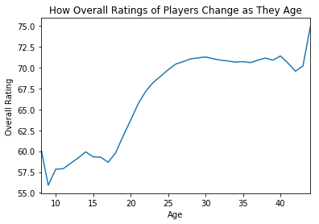

```python
# Plot the average rating by Age
full_players_df.groupby('Age')['overall_rating'].mean().plot(kind='line')
plt.title('How Overall Ratings of Players Change as They Age')
plt.xlabel('Age')
plt.ylabel('Overall Rating');
```

#### Key Finding #1

It is surprising that we see a spike in player ratings at the beginning and end of this curve. My current working assumption is that players at the ends of these curves are outliers and probably a low sample of players. It is quite obvious that players under 14 are most definitely outliers.

Let's take a look at counts and a histogram of player age.

```python
# Let's then store the description of the data
full_players_df.groupby('Age')['overall_rating'].describe()
```

| Age | count | mean | std | min | 25% | 50% | 75% | max |
| --- | --- | --- | --- | --- | --- | --- | --- | --- |
| 8.0 | 8.0 | 60.500000 | 7.502381 | 46.0 | 56.75 | 62.0 | 64.75 | 70.0 |
| 9.0 | 36.0 | 55.916667 | 4.519007 | 47.0 | 52.00 | 56.0 | 59.00 | 66.0 |
| 10.0 | 143.0 | 57.839161 | 4.632479 | 49.0 | 54.00 | 58.0 | 61.00 | 71.0 |
| 11.0 | 260.0 | 57.896154 | 4.640844 | 49.0 | 55.00 | 58.0 | 61.00 | 72.0 |
| 12.0 | 349.0 | 58.558739 | 5.306699 | 43.0 | 55.00 | 59.0 | 62.00 | 73.0 |
| 13.0 | 494.0 | 59.186235 | 5.212885 | 47.0 | 55.25 | 59.0 | 63.00 | 75.0 |
| 14.0 | 573.0 | 59.917976 | 5.338072 | 44.0 | 56.00 | 60.0 | 64.00 | 74.0 |
| 15.0 | 629.0 | 59.319555 | 6.193119 | 40.0 | 55.00 | 60.0 | 63.00 | 75.0 |
| 16.0 | 727.0 | 59.283356 | 6.416837 | 39.0 | 55.00 | 60.0 | 64.00 | 76.0 |
| 17.0 | 1178.0 | 58.672326 | 6.682222 | 35.0 | 54.00 | 59.0 | 63.00 | 82.0 |
| 18.0 | 3266.0 | 59.803429 | 6.674167 | 36.0 | 55.25 | 60.0 | 64.00 | 83.0 |
| 19.0 | 6730.0 | 61.821100 | 6.678159 | 33.0 | 57.00 | 62.0 | 66.00 | 84.0 |
| 20.0 | 9569.0 | 63.719093 | 6.804368 | 33.0 | 59.00 | 64.0 | 68.00 | 86.0 |
| 21.0 | 11543.0 | 65.664992 | 6.684653 | 35.0 | 61.00 | 66.0 | 70.00 | 93.0 |
| 22.0 | 12880.0 | 67.153960 | 6.437511 | 41.0 | 63.00 | 67.0 | 72.00 | 90.0 |
| 23.0 | 13572.0 | 68.227969 | 6.349048 | 36.0 | 64.00 | 68.0 | 73.00 | 91.0 |
| 24.0 | 14189.0 | 68.972021 | 6.307325 | 40.0 | 65.00 | 69.0 | 73.00 | 94.0 |
| 25.0 | 14339.0 | 69.746286 | 6.210050 | 40.0 | 65.00 | 70.0 | 74.00 | 94.0 |
| 26.0 | 14063.0 | 70.426296 | 6.359425 | 38.0 | 66.00 | 70.0 | 75.00 | 94.0 |
| 27.0 | 13798.0 | 70.725902 | 6.243874 | 45.0 | 66.00 | 71.0 | 75.00 | 94.0 |
| 28.0 | 12568.0 | 71.061903 | 6.133847 | 38.0 | 67.00 | 71.0 | 75.00 | 94.0 |
| 29.0 | 10833.0 | 71.181298 | 6.136450 | 45.0 | 67.00 | 71.0 | 75.00 | 94.0 |
| 30.0 | 9306.0 | 71.286374 | 6.031601 | 47.0 | 67.00 | 71.0 | 75.00 | 92.0 |
| 31.0 | 7841.0 | 71.076393 | 5.959100 | 52.0 | 67.00 | 71.0 | 75.00 | 93.0 |
| 32.0 | 6386.0 | 70.904009 | 5.908943 | 42.0 | 67.00 | 71.0 | 75.00 | 92.0 |
| 33.0 | 5202.0 | 70.804306 | 5.744325 | 43.0 | 67.00 | 71.0 | 75.00 | 90.0 |
| 34.0 | 3860.0 | 70.666839 | 5.676280 | 43.0 | 67.00 | 71.0 | 74.00 | 92.0 |
| 35.0 | 2688.0 | 70.729539 | 5.779485 | 51.0 | 66.00 | 71.0 | 75.00 | 87.0 |
| 36.0 | 1516.0 | 70.609499 | 5.883850 | 52.0 | 66.00 | 70.0 | 75.00 | 87.0 |
| 37.0 | 860.0 | 70.906977 | 5.928028 | 54.0 | 66.00 | 71.0 | 75.00 | 85.0 |
| 38.0 | 450.0 | 71.162222 | 5.755826 | 57.0 | 67.00 | 71.0 | 75.00 | 85.0 |
| 39.0 | 244.0 | 70.901639 | 5.578338 | 58.0 | 67.00 | 71.0 | 75.00 | 83.0 |
| 40.0 | 137.0 | 71.408759 | 5.632828 | 60.0 | 68.00 | 71.0 | 76.00 | 83.0 |
| 41.0 | 60.0 | 70.550000 | 5.334331 | 58.0 | 67.00 | 69.0 | 74.25 | 81.0 |
| 42.0 | 41.0 | 69.585366 | 5.499889 | 58.0 | 65.00 | 68.0 | 74.00 | 80.0 |
| 43.0 | 14.0 | 70.214286 | 6.506548 | 58.0 | 66.00 | 68.0 | 76.75 | 79.0 |
| 44.0 | 2.0 | 75.000000 | 2.828427 | 73.0 | 74.00 | 75.0 | 76.00 | 77.0 |

A Histogram of the Player Ages shows a very small number of players at edges. These outliers are making the Player Age by Overall Rating chart look unrealistic. We should remove these players from our analysis.

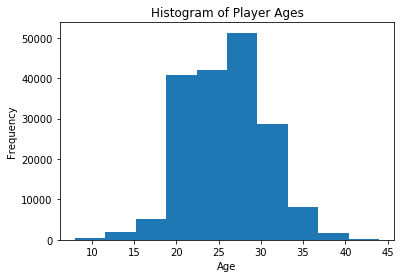

```python
full_players_df['Age'].plot(kind='hist')
plt.title('Histogram of Player Ages')
plt.xlabel('Age')
###plt.ylabel('Frequency');
```

### Additional Data Wrangling is Needed.

#### Let's create a new df filtering out the outliers.

We've confirmed that 2 players who are 44 are skewing our curve that top end of the age bracket, while there are 8 players at the lower end of the bracket skewing our results in a similar fashion. Clearly if they are 8 years old, there is probably somthing wrong with this data, so it makes sense to exclude them from our analysis.

I'm going to create a new age_df with ages ranging from 14 to 37 with sample sizes greater than 500.

```python
full_players_df['Age'].mean()
```

```
25.674889384211053
```

```python
# Source: https://stackoverflow.com/questions/31617845/how-to-select-rows-in-a-dataframe-between-two-values-in-python-pandas
age_df = full_players_df[(full_players_df['Age']>= 14) & (full_players_df['Age']<=37)]
```

```python
age_df['Age'].mean()
```

```
25.704108558467517
```

Removing players with a sample less than 500 didn't really change the mean much. But atleast it should questions about the validity of the dataset.

### Age vs. Overall Rating

#### Key Finding # 2:

After 30, things start to go downhill. Player ratings start a slow decline, but don't actually decline as quickly as I would have thought.

Let's check out some other player attributes and see how they change as we age. Speed must decline as we age!

[figure not shown]

```python
age_df.groupby('Age')['overall_rating'].mean().plot(kind='line')
plt.title('How Mean Overall Player Ratings Change as They Age')
plt.xlabel('Age')
## ##plt.ylabel('Overall Rating (mean)');
```

### A Review of Select Player Attributes vs. Age

Out of interest, I want to review how a player's speed, vision, ability to finish, shot power and their overall potential changes over time. Let's see what we find out. First up, Age vs. Speed.

### Age vs. Speed

#### Key Finding # 3: Age vs. Sprint Speed

Player speed seems to peak around age 24 and starts rapidly decline as players age.

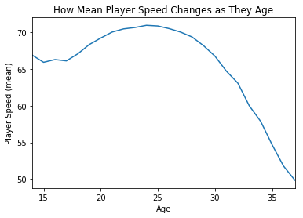

```python
age_df.groupby('Age')['sprint_speed'].mean().plot(kind='line')
plt.title('How Mean Player Speed Changes as They Age')
plt.xlabel('Age')
plt.ylabel('Player Speed (mean)');
```

#### What is the Relationship / Correlation between Age and Speed?

There is a negative correlation -0.21 between age and speed. It is interesting that the scatterplot visual didn't seem to clearly show the decline in speed in comparison to the visualization of the mean. This is something I did not fully expect.

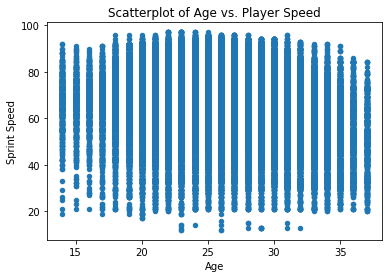

```python
age_df.plot(x='Age', y='sprint_speed', kind='scatter');
plt.title('Scatterplot of Age vs. Player Speed')
plt.xlabel('Age')
plt.ylabel('Sprint Speed');
```

```python
age_df['Age'].corr(full_players_df['sprint_speed'])
```

```
-0.21148981955428395
```

### Age vs. Finishing

#### Key Finding #4

Similar to speed, we see the mean decline as players age across their ability to finish, how well they see play on the pitch (vision) and shot power.

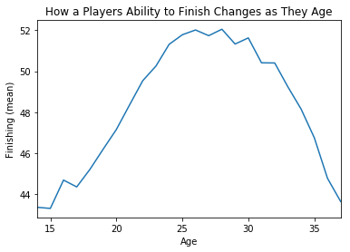

```python
# Player Age vs. Finishing
age_df.groupby('Age')['finishing'].mean().plot(kind='line')
plt.title('How a Players Ability to Finish Changes as They Age')
plt.xlabel('Age')
plt.ylabel('Finishing (mean)');
```

### Age vs. Vision

A players vision doesn't seem to drop off nearly as quickly as a player's mean sprint speed.

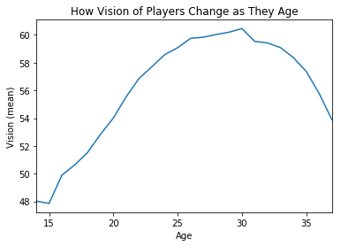

```python
# Player Age vs. Vision
age_df.groupby('Age')['vision'].mean().plot(kind='line')
plt.title('How Vision of Players Change as They Age')
plt.xlabel('Age')
plt.ylabel('Vision (mean)');
```

### Age vs. Shot Power

Similar to player vision, we see that shot seems to start really dropping off around the age of 32.

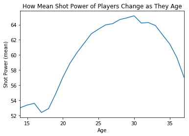

```python
# Player Age vs. Shot Power
age_df.groupby('Age')['shot_power'].mean().plot(kind='line')
plt.title('How Mean Shot Power of Players Change as They Age')
plt.xlabel('Age')
plt.ylabel('Shot Power (mean)');
```

### Age vs. Player Potential

#### Key Finding #5

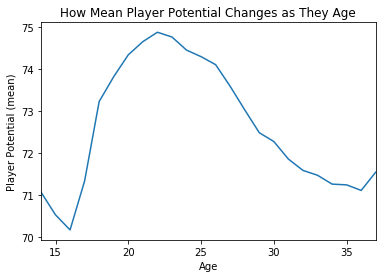

```python
age_df.groupby('Age')['potential'].mean().plot(kind='line')
plt.title('How Mean Player Potential Changes as They Age')
plt.xlabel('Age')
plt.ylabel('Player Potential (mean)');
```

### OK...there must be something that doesn't decline as we age...what about weight?

#### Key Finding #6

As confirmed, mean player weight grows as players get older.

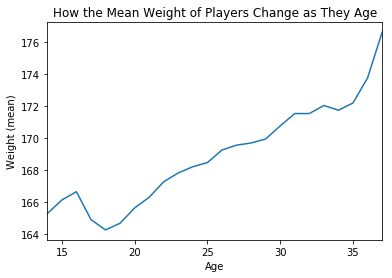

```python
age_df.groupby('Age')['weight'].mean().plot(kind='line')
plt.title('How the Mean Weight of Players Change as They Age')
plt.xlabel('Age')
plt.ylabel('Weight (mean)');
```

#### The Relationship between Weight and Speed = Inverse

As player weight increases, we see player speed decline.

```python
age_df['weight'].corr(full_players_df['sprint_speed'])
```

```
-0.38329541772313941
```

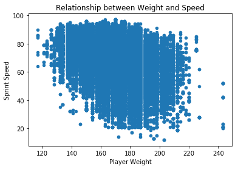

```python
age_df.plot(x='weight', y='sprint_speed', kind='scatter');
plt.title('Relationship between Weight and Speed')
plt.xlabel('Player Weight')
plt.ylabel('Sprint Speed');
```

### Conclusion and Key Learnings

#### So what happens as players age?

From the time that a player is approximately 16 years old, we begin to see a steady rise in their mean overall ability (rating). Players on average tend to peak in ability as they approach 30 and then gradually start to decline in ability.

Of the 5 attributes analyzed, only one continued to grow as players got older, that being player weight. Player weight also had a mild negative relationship with player speed which isn't too surprising. As we get heavier, we tend to get slower.

#### Key Learnings about this Project

I learned a lot about how to use python for this project. Originally, the outline of the project recommended doing a lot of the querying within a sqlite program called DB Browser. I really enjoy using Jupyter for analysis and decided to search of a python sqlite library and found sqlite3. This worked out really well and I was able to quickly import each table into their own dataframe and start the analysis.

On the analysis side, I knew that as we age we decline in physical ability. This makes logical sense. What I didn't know was how different aspects of our physical abilities decline and at what time. This was what I was interested in and wanted to see the data behind these declines.

One other thing that kind of surprised me was how using the mean was much more visually effective at showing how player attributes and ratings change as they age vs. using a scatterplot. In hindsite, it makes sense, you get see the rise and fall of player ratings. But at the time I was originally inclined to do a scatterplot analysis.

#### Limitations & Other Analysis Considerations.

One of the key limitations of my analysis, was really unpacking why we see significant drop-off in player attributes but not seeing a similar drop-off in the mean players overall rating. I would love to understand what could be driving the slow decline in player ratings after 30. Better understanding how the overall rating was calculated would help me feel more comfortable with that finding.

I had originally included a multiple regression of the overall rating vs. all of the other attributes and found the 'reaction' attribute had the highest coefficient value. I decided not to include this in the analysis, but thought it would help me better understand what influences that overall rating. I was also unsure if my interpretation of that result was correct and would like to explore this again.

### Online References

Here is a summary of articles that I referenced as I conducted this analysis. Some of these were not included in the final submission:

1) Stackoverflow:  
a) https://stackoverflow.com/questions/31617845/how-to-select-rows-in-a-dataframe-between-two-values-in-python-pandas  
b) https://stackoverflow.com/questions/32965589/find-min-max-and-average-of-an-id-in-python-pandas  
c) https://stackoverflow.com/questions/37840812/pandas-subtracting-two-date-columns-and-the-result-being-an-integer  
d) https://stackoverflow.com/questions/42579908/use-corr-to-get-the-correlation-between-two-columns?utm_medium=organic&utm_source=google_rich_qa&utm_campaign=google_rich_qa

2) https://www.learndatasci.com/tutorials/predicting-housing-prices-linear-regression-using-python-pandas-statsmodels/  
3) Python sqlite3 connector: https://www.dataquest.io/blog/python-pandas-databases/